# Static map projection comparison

Dataspice metadata reports · Projection-selection prototype · 12 test extents

## Abstract

Archived dataspice HTML reports can lose their interactive maps when browser restrictions or OpenStreetMap tile-policy blocks prevent Leaflet tiles from loading. This report compares four static-map projection strategies across 12 bounding boxes, using a shared map background, coverage outline, graticule, and Equal Earth locator inset. This research addresses [dataspice issue #123](https://github.com/ropensci/dataspice/issues/123); map images are embedded for offline viewing.

## Methods

Every main map uses the same world geometry and coverage box, plus a 10° latitude/longitude graticule with labeled ticks, with longitude labels thinned for broad extents and exact-pole labels omitted where meridians converge; the inset uses a fixed Equal Earth view. The selector below changes the grid previews and all detailed maps together. IDs e01–e12 identify test extents; m01–m04 identify projection methods.

[output not shown]

Select main-map projection method

## Test extent catalogue

Select a thumbnail to jump to its detailed figure. Browser Back returns to the catalogue.

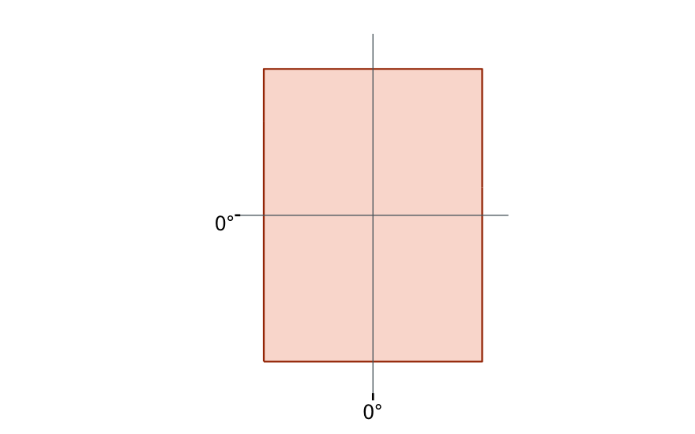

**e01** equator_tiny_square+proj=eqearth +lon_0=0.00000000 +datum=WGS84 +units=m +no_defs +over

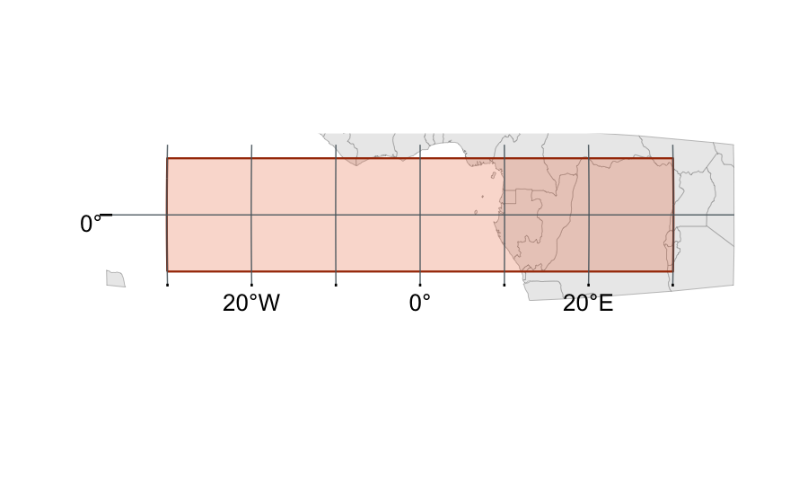

**e02** equator_wide+proj=eqearth +lon_0=0.00000000 +datum=WGS84 +units=m +no_defs +over

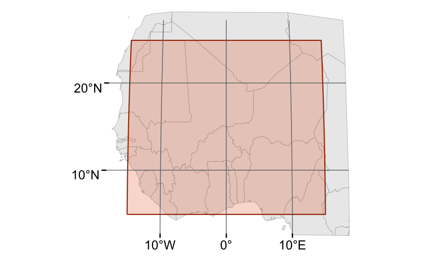

**e03** prime_meridian_crossing+proj=eqearth +lon_0=0.00000000 +datum=WGS84 +units=m +no_defs +over

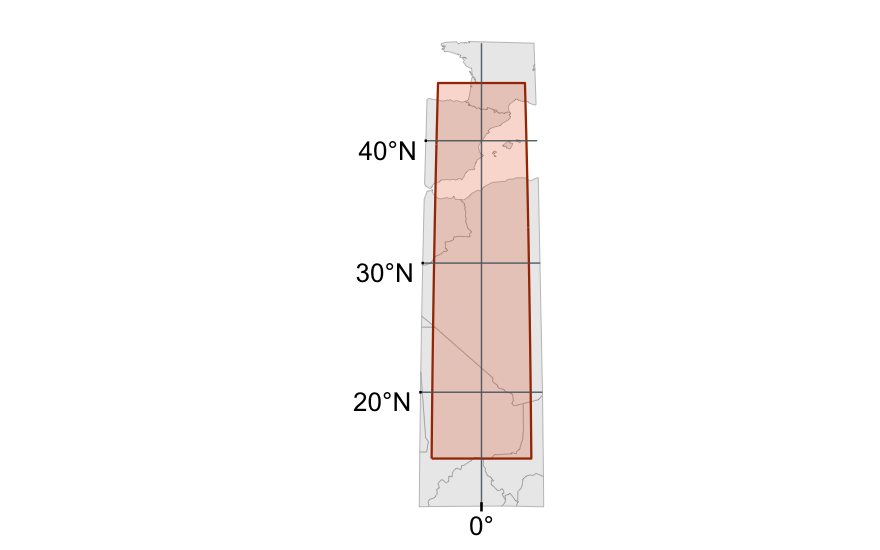

**e04** midlatitude_tall+proj=eqearth +lon_0=0.00000000 +datum=WGS84 +units=m +no_defs +over

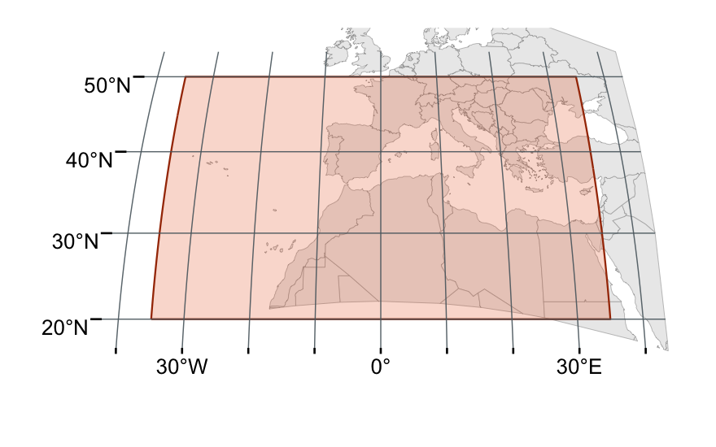

**e05** midlatitude_wide+proj=eqearth +lon_0=0.00000000 +datum=WGS84 +units=m +no_defs +over

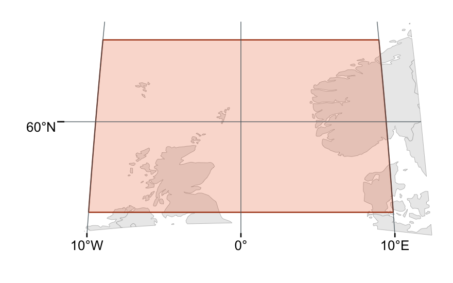

**e06** highlatitude_square+proj=eqearth +lon_0=0.00000000 +datum=WGS84 +units=m +no_defs +over

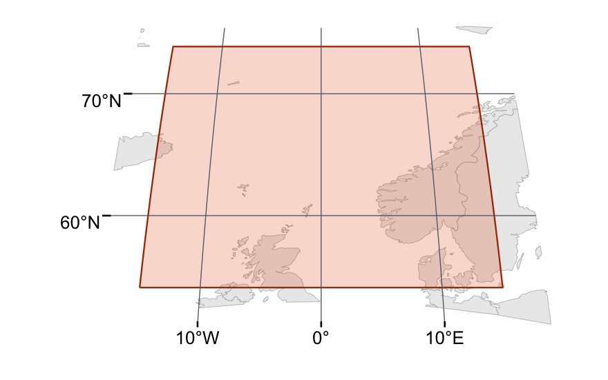

**e07** highlatitude_tall+proj=eqearth +lon_0=0.00000000 +datum=WGS84 +units=m +no_defs +over

[figure not shown]

**e09** north_polar_cap+proj=eqearth +lon_0=0.00000000 +datum=WGS84 +units=m +no_defs +over

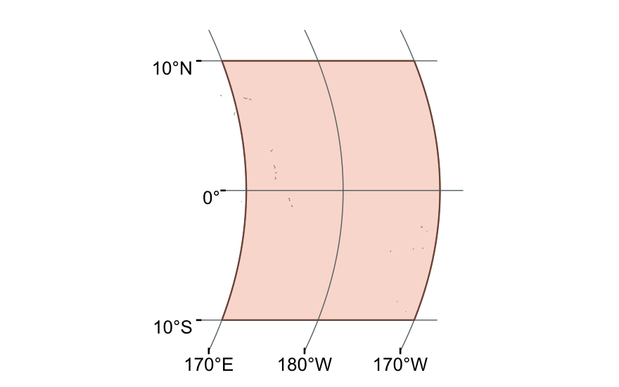

**e10** antimeridian_small+proj=eqearth +lon_0=-180.00000000 +datum=WGS84 +units=m +no_defs +over

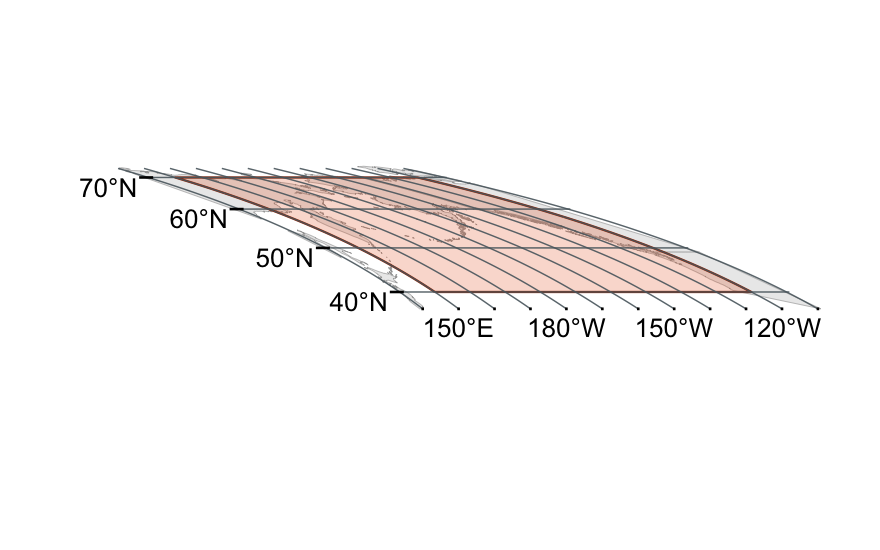

**e11** antimeridian_regional+proj=eqearth +lon_0=-165.00000000 +datum=WGS84 +units=m +no_defs +over

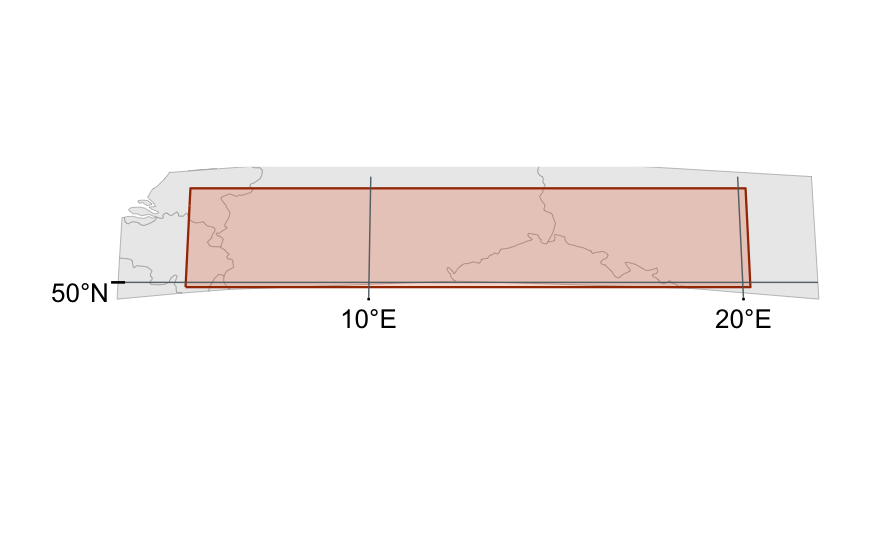

**e12** issue_123_zenodo_extent+proj=eqearth +lon_0=12.65000000 +datum=WGS84 +units=m +no_defs +over

## e01 — equator_tiny_square

`north=2, east=2, south=-2, west=-2` · center 0° · Small square centered on equator

Back to example grid ↑

### Figure e01 · m01 — Equal Earth

Equal Earth, centered on bbox

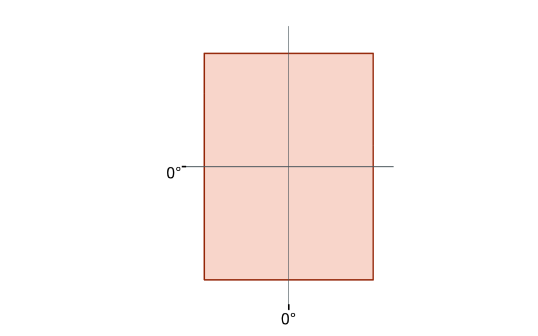

### Figure e01 · m02 — crsuggest top-ranked CRS

Accra / TM 1 NW (EPSG:2137)

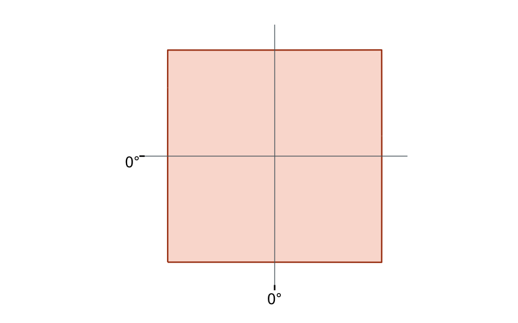

### Figure e01 · m03 — projWiz equal-area selection

projWiz::proj_region(property = 'Equal area'): +proj=laea +lon_0=0 +lat_0=0 +datum=WGS84 +units=m +no_defs

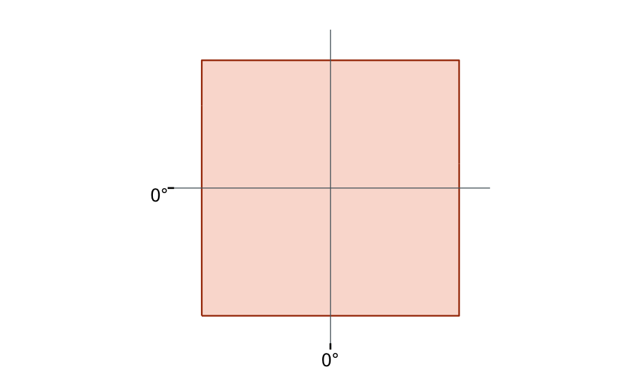

### Figure e01 · m04 — Custom extent-aware equal-area

Compact extent (<1,000 km) → locally centered LAEA

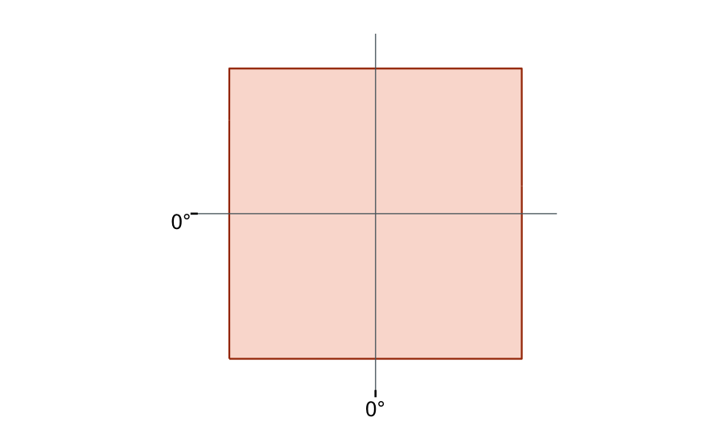

## e02 — equator_wide

`north=5, east=30, south=-5, west=-30` · center 0° · Large east-west extent centered on equator

Back to example grid ↑

### Figure e02 · m01 — Equal Earth

Equal Earth, centered on bbox

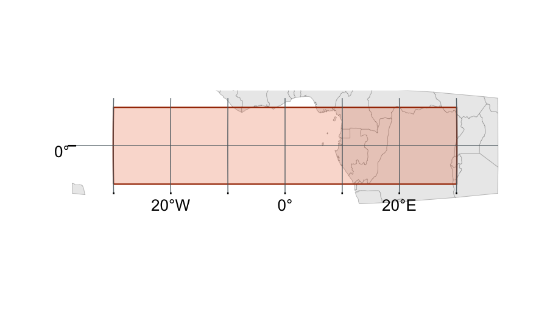

### Figure e02 · m02 — crsuggest top-ranked CRS

Leigon / Ghana Metre Grid (EPSG:25000)

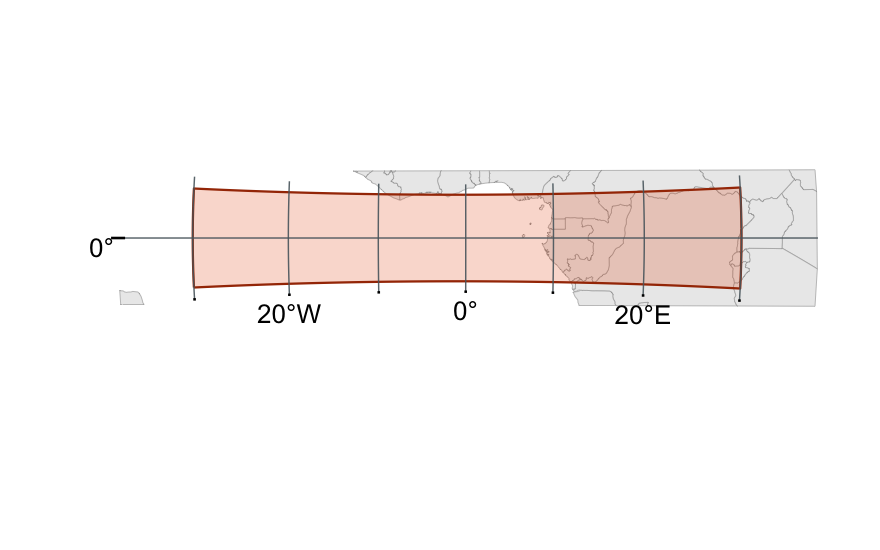

### Figure e02 · m03 — projWiz equal-area selection

projWiz::proj_region(property = 'Equal area'): +proj=cea +lon_0=0 +lat_ts=2.5 +datum=WGS84 +units=m +no_defs

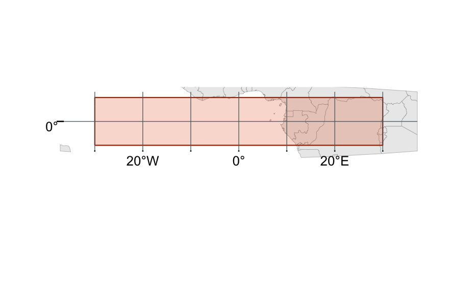

### Figure e02 · m04 — Custom extent-aware equal-area

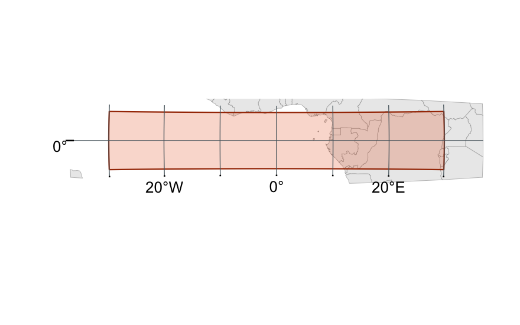

## e03 — prime_meridian_crossing

`north=25, east=15, south=5, west=-15` · center 15° · Crosses Greenwich meridian; regional east-west extent

Back to example grid ↑

### Figure e03 · m01 — Equal Earth

Equal Earth, centered on bbox

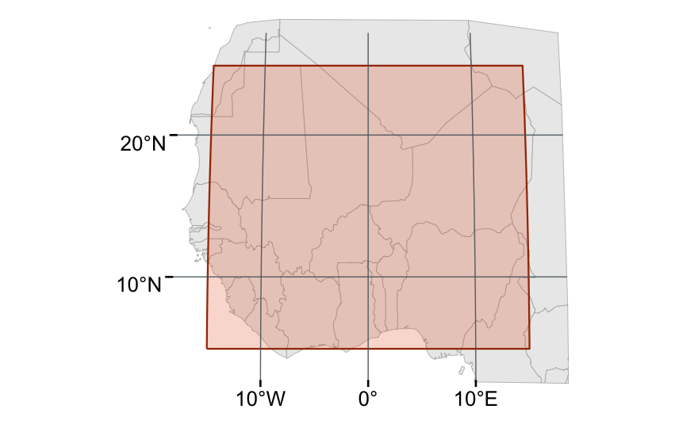

### Figure e03 · m02 — crsuggest top-ranked CRS

Lome / UTM zone 31N (EPSG:25231)

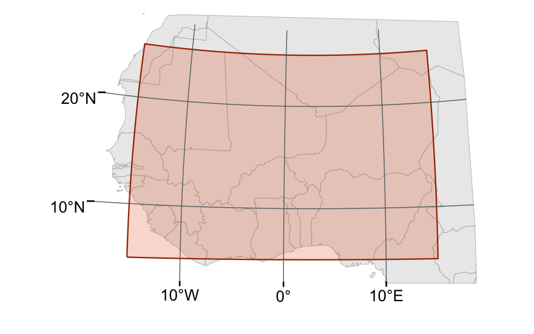

### Figure e03 · m03 — projWiz equal-area selection

projWiz::proj_region(property = 'Equal area'): +proj=aea +lon_0=0 +lat_1=8.3333333 +lat_2=21.6666667 +lat_0=15 +datum=WGS84 +units=m +no_defs

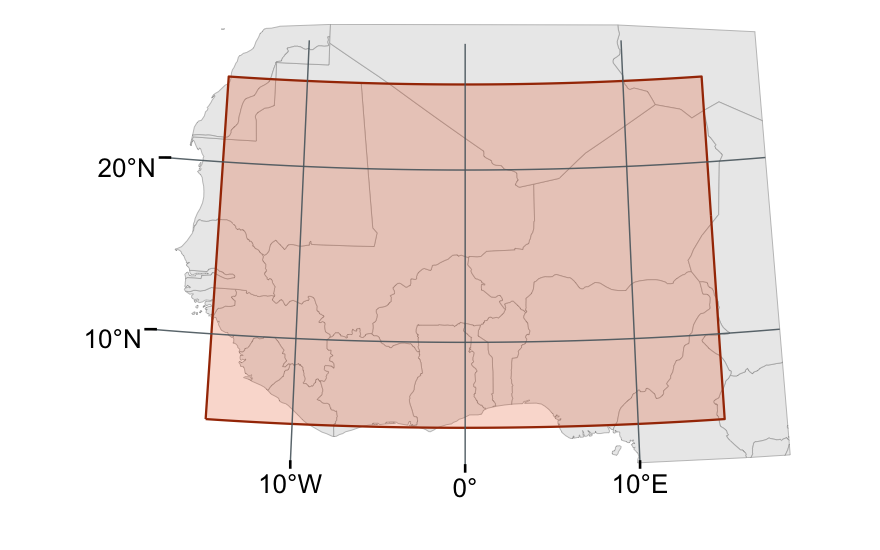

### Figure e03 · m04 — Custom extent-aware equal-area

Wide extent (width/height 1.45) → Albers equal-area conic

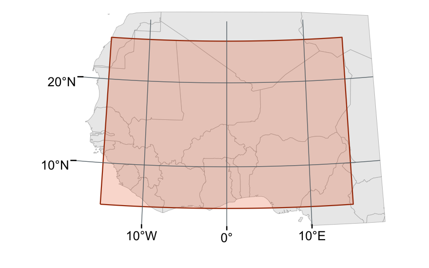

## e04 — midlatitude_tall

`north=45, east=5, south=15, west=-5` · center 30° · Tall north-south extent centered near 30N

Back to example grid ↑

### Figure e04 · m01 — Equal Earth

Equal Earth, centered on bbox

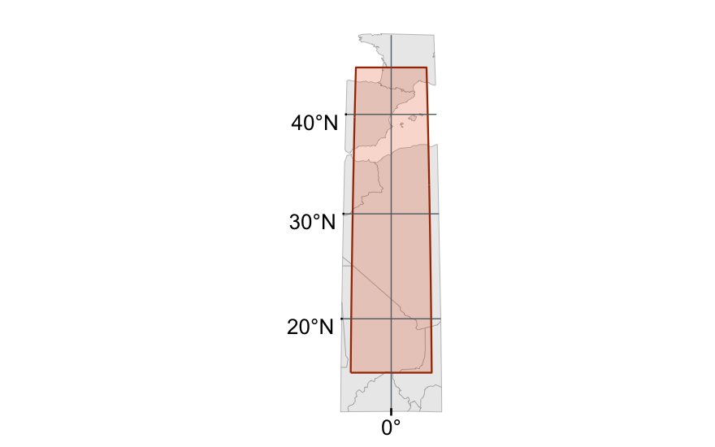

### Figure e04 · m02 — crsuggest top-ranked CRS

Nord Sahara 1959 / UTM zone 31N (EPSG:30731)

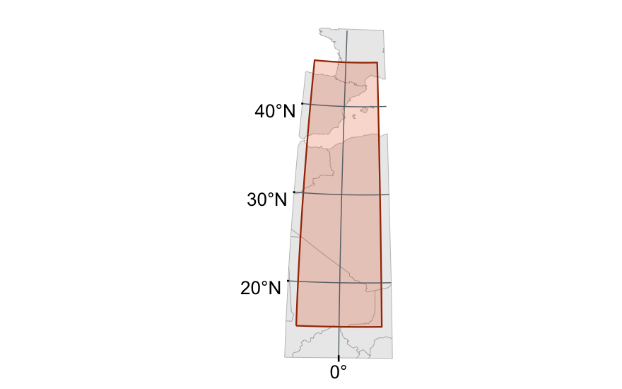

### Figure e04 · m03 — projWiz equal-area selection

projWiz::proj_region(property = 'Equal area'): +proj=tcea +lon_0=0 +datum=WGS84 +units=m +no_defs

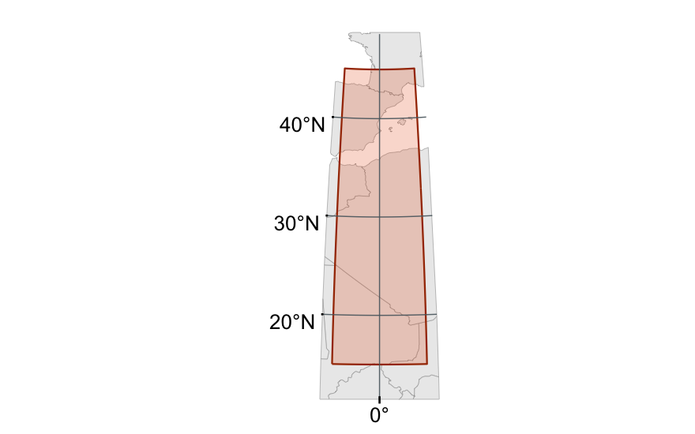

### Figure e04 · m04 — Custom extent-aware equal-area

Tall/square extent (width/height 0.29) → local LAEA

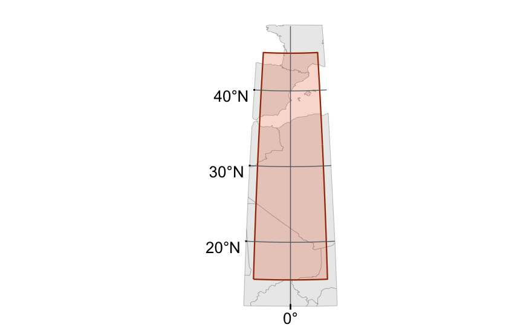

## e05 — midlatitude_wide

`north=50, east=35, south=20, west=-35` · center 35° · Large east-west continental extent near 35N

Back to example grid ↑

### Figure e05 · m01 — Equal Earth

Equal Earth, centered on bbox

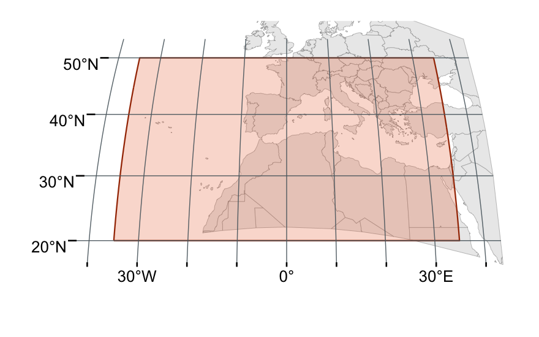

### Figure e05 · m02 — crsuggest top-ranked CRS

ETRS89-extended / LAEA Europe (EPSG:3035)

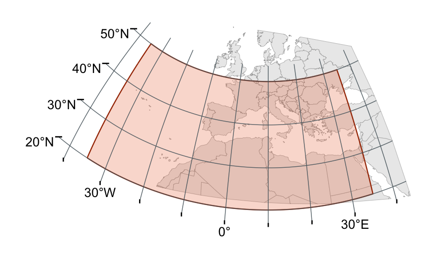

### Figure e05 · m03 — projWiz equal-area selection

projWiz::proj_region(property = 'Equal area'): +proj=aea +lon_0=0 +lat_1=25 +lat_2=45 +lat_0=35 +datum=WGS84 +units=m +no_defs

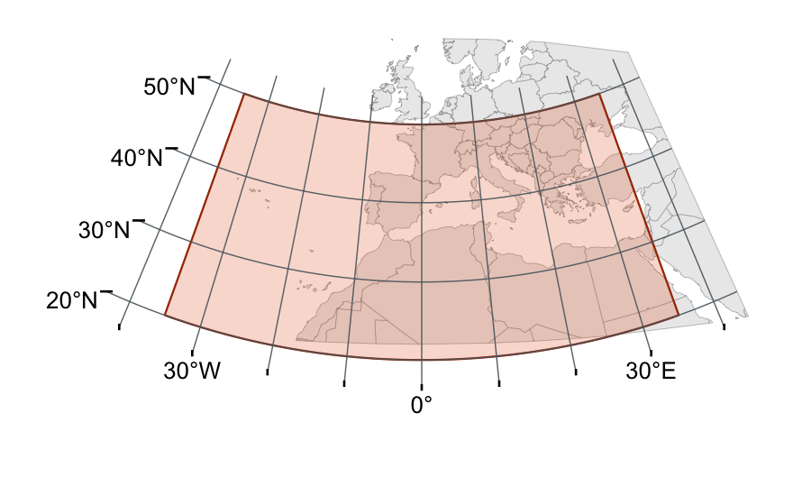

### Figure e05 · m04 — Custom extent-aware equal-area

Wide extent (width/height 1.91) → Albers equal-area conic

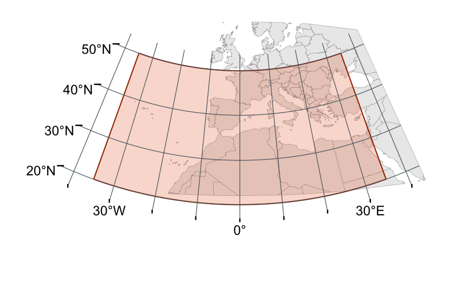